# Data Science Capstone Project: Milestone Report

voxxys

Sunday, March 29, 2015

## The dataset

The data which we will use for building our prediction model comes from a corpus called **HC Corpora** (www.corpora.heliohost.org). The readme file containing the details for the corpora available can be accessed at http://www.corpora.heliohost.org/aboutcorpus.html.

There are 3 text files for the English language: - **en_Us.twitter.txt** - **en_Us.blogs.txt** - **en_Us.news.txt**

The files can be found in the **en_US** folder.

```r
con <- file("en_US/en_US.twitter.txt", "r")
c_twitter <- readLines(con);
con <- file("en_US/en_US.blogs.txt", "r")
c_blogs <- readLines(con);

con <- file("en_US/en_US.news.txt", "r")
c_news <- readLines(con);
```

## Exploratory Data Analysis

The first file, en_Us.twitter.txt, contains 2360148 lines:

```r
length(c_twitter);
```

```
## [1] 2360148
```

We can also find the total number of words in this file:

```r
countwords <- function(somestring) {
  result <- sapply(gregexpr("\\W+", somestring), length) + 1;
  return(result);

}

wordcount1 <- lapply(c_twitter,countwords);
temp1 <- unlist(wordcount1);
wordcount1 <- sum(temp1);
wordcount1
```

```
## [1] 32874008
```

The distribution of entry length for en_Us.twitter.txt file:

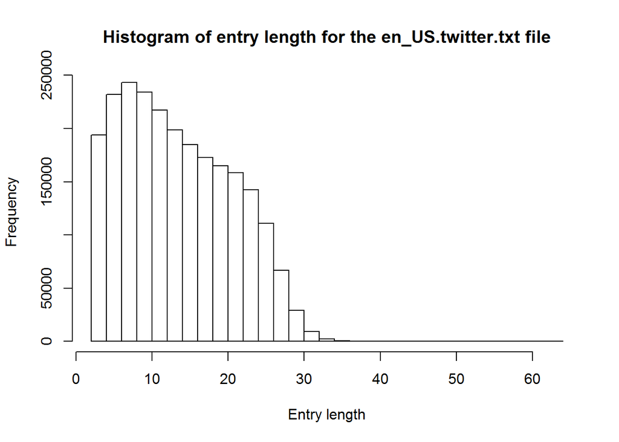

```r
hist(temp1,main = paste("Histogram of entry length for the en_US.twitter.txt file"),xlab = "Entry length");
```

Example of entries from the file:

```r
head(c_twitter);
```

```
## [1] "How are you? Btw thanks for the RT. You gonna be in DC anytime soon? Love to see you. Been way, way too long."
## [2] "When you meet someone special... you'll know. Your heart will beat more rapidly and you'll smile for no reason."
## [3] "they've decided its more fun if I don't."
## [4] "So Tired D; Played Lazer Tag & Ran A LOT D; Ughh Going To Sleep Like In 5 Minutes ;)"
## [5] "Words from a complete stranger! Made my birthday even better :)"
## [6] "First Cubs game ever! Wrigley field is gorgeous. This is perfect. Go Cubs Go!"
```

The file en_Us.blogs.txt contains 899288 lines:

```r
length(c_blogs);
```

```
## [1] 899288
```

The total number of words in this file:

```r
wordcount2 <- lapply(c_blogs,countwords);
temp2 <- unlist(wordcount2);
wordcount2 <- sum(temp2);
wordcount2
```

```
## [1] 39386844
```

The distribution of entry length for en_Us.blogs.txt file:

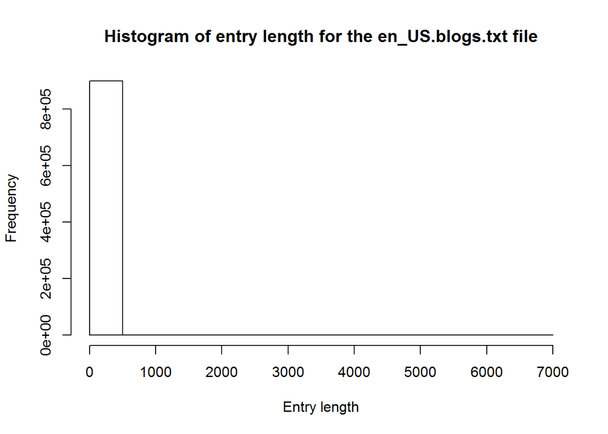

```r
hist(temp2,main = paste("Histogram of entry length for the en_US.blogs.txt file"),xlab = "Entry length");
```

Example of entries from the file:

```r
head(c_blogs);
```

```
## [1] "In the years thereafter, most of the Oil fields and platforms were named after pagan вЂњgodsвЂќ."
## [2] "We love you Mr. Brown."
## [3] "Chad has been awesome with the kids and holding down the fort while I work later than usual! The kids have been busy together playing Skylander on the XBox together, after Kyan cashed in his $$$ from his piggy bank. He wanted that game so bad and used his gift card from his birthday he has b…
## [4] "so anyways, i am going to share some home decor inspiration that i have been storing in my folder on the puter. i have all these amazing images stored away ready to come to life when we get our home."
## [5] "With graduation season right around the corner, Nancy has whipped up a fun set to help you out with not only your graduation cards and gifts, but any occasion that brings on a change in one's life. I stamped the images in Memento Tuxedo Black and cut them out with circle Nestabilities. I emb…
## [6] "If you have an alternative argument, let's hear it! :)"
```

The file en_Us.news.txt contains 77259 lines:

```r
length(c_news);
```

```
## [1] 77259
```

The total number of words in this file:

```r
wordcount3 <- lapply(c_news,countwords);
temp3 <- unlist(wordcount3);
wordcount3 <- sum(temp3);
wordcount3
```

```
## [1] 2837489
```

The distribution of entry length for en_Us.news.txt file:

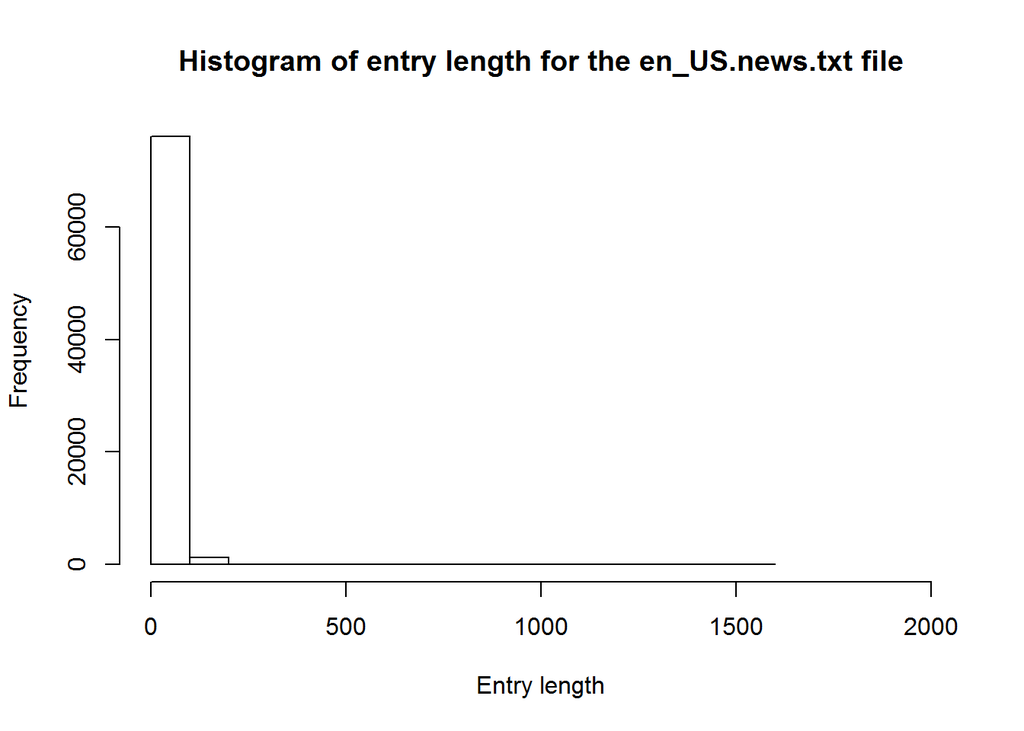

```r
hist(temp3,main = paste("Histogram of entry length for the en_US.news.txt file"),xlim = c(0,2000),xlab = "Entry length");
```

Example of entries from the file:

```r
head(c_news)
```

```
## [1] "He wasn't home alone, apparently."
## [2] "The St. Louis plant had to close. It would die of old age. Workers had been making cars there since the onset of mass automotive production in the 1920s."
## [3] "WSU's plans quickly became a hot topic on local online sites. Though most people applauded plans for the new biomedical center, many deplored the potential loss of the building."
## [4] "The Alaimo Group of Mount Holly was up for a contract last fall to evaluate and suggest improvements to Trenton Water Works. But campaign finance records released this week show the two employees donated a total of $4,500 to the political action committee (PAC) Partners for Progress in early…
## [5] "And when it's often difficult to predict a law's impact, legislators should think twice before carrying any bill. Is it absolutely necessary? Is it an issue serious enough to merit their attention? Will it definitely not make the situation worse?"
## [6] "There was a certain amount of scoffing going around a few years ago when the NFL decided to move the draft from the weekend to prime time -- eventually splitting off the first round to a separate day."
```

## The prediction model

To create a word prediction application, it is useful to analyse the frequency of words and word constructions that appear in the given files. Such analysis can be easily performed using *tm* and *RWeka* libraries.

For the given corpora, n-grams (sequences of n words) can be found and sorted by frequency. Then a Markow n-gram probability model can be built to predict the next word for a given phrase.